# Desafio de Séries Temporais II

Arthur Hintz, Beatriz Buffon, Jonatan Araujo , Yasmin Pires

27 mai 2025

# Introdução

O presente relatório tem como objetivo analisar a série temporal referente à **velocidade média do vento** registrada em Brasília, com dados obtidos da estação meteorológica **83377**. A série temporal compreende medições mensais de velocidade média do vento (em metros por segundo) e velocidade máxima média, coletadas no intervalo entre **janeiro de 2001** e **dezembro de 2018**.

Brasília, localizada no Planalto Central, apresenta características climáticas peculiares, influenciadas por sua altitude elevada e pela presença de estações bem definidas, como a estação chuvosa e a seca. A velocidade do vento desempenha um papel importante no clima local, influenciando não apenas a temperatura percebida, mas também a dispersão de poluentes e outros processos atmosféricos relevantes.

A análise da série temporal permitirá identificar padrões sazonais, tendências e possíveis mudanças ao longo do tempo nos dados coletados. Serão aplicadas técnicas estatísticas e gráficas, como decomposição da série, testes de estacionariedade e modelagens adequadas, com o intuito de explorar e modelar os comportamentos observados.

# Bancos de Dados

Nesta seção, apresentamos as **três primeiras** e **três últimas observações** da série temporal de velocidade média do vento e velocidade máxima média, a fim de ilustrar o início e o final do período analisado.

A tabela mostra que a base de dados se estende de **janeiro de 2001** até **dezembro de 2018**, com medições mensais consistentes ao longo de **216 observações**. As variáveis principais são:

1. **VelocidadeVentoMedia**: Velocidade média do vento no mês, em metros por segundo.
2. **VelocidadeVentoMaximaMedia**: Velocidade máxima média do vento no mês, em metros por segundo.

Três primeiros e três últimas observações da série temporal

|  | Data | Hora | VelocidadeVentoMedia | VelocidadeVentoMaximaMedia |
| --- | --- | --- | --- | --- |
| 1 | 2001-01-31 | 0 | 2.419355 | 12.00000 |
| 2 | 2001-02-28 | 0 | 1.778571 | 7.00000 |
| 3 | 2001-03-31 | 0 | 1.844444 | 9.00000 |
| 214 | 2018-10-31 | 0 | 1.371840 | 7.20216 |
| 215 | 2018-11-30 | 0 | 1.897712 | 9.77436 |
| 216 | 2018-12-31 | 0 | 1.703737 | 6.17328 |

# Análise Exploratória

### Série Observada

Nesta seção, analisamos o **comportamento da série temporal** de velocidade média do vento em Brasília ao longo do tempo. A tabela a seguir apresenta as **estatísticas descritivas** da variável **VelocidadeVentoMedia**:

```
##    Min. 1st Qu.  Median    Mean 3rd Qu.    Max.
##  0.6921  1.6903  2.0367  2.1012  2.4309  4.5054
```

Abaixo, apresentamos o **gráfico da série temporal** da velocidade média do vento:

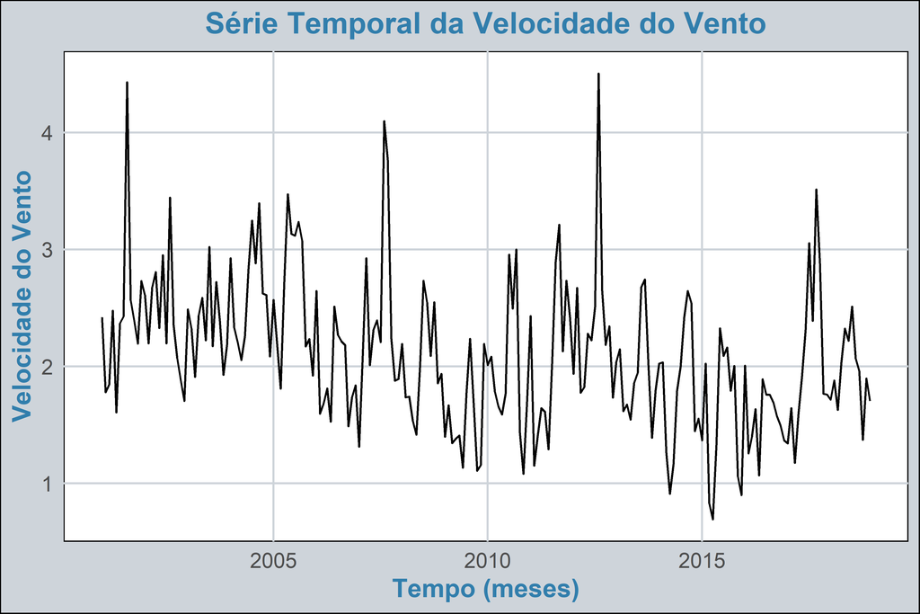

O gráfico abaixo apresenta a **sobreposição da velocidade média do vento** em Brasília para os anos de **2001, 2004, 2007, 2010, 2013 e 2016**.

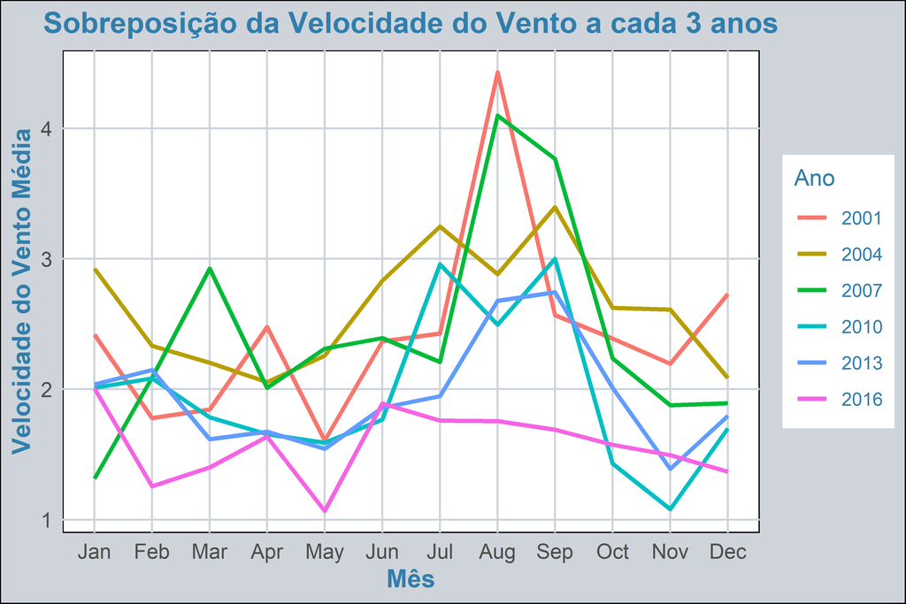

O gráfico abaixo apresenta as **médias** por mês, acompanhadas de **barras de erro**, que representam o desvio padrão dos valores.

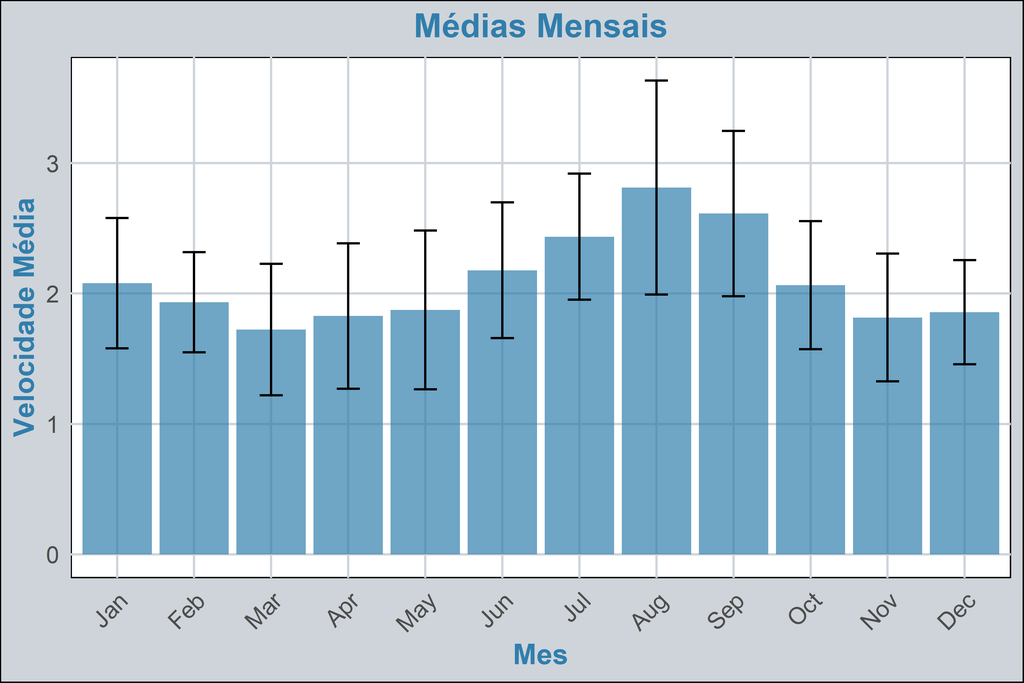

### Gráfico da Função de Autocorrelação (FAC)

Para identificar dependências temporais na série de **velocidade média do vento**, foi calculada a **Função de Autocorrelação (ACF)**, apresentada no gráfico abaixo.

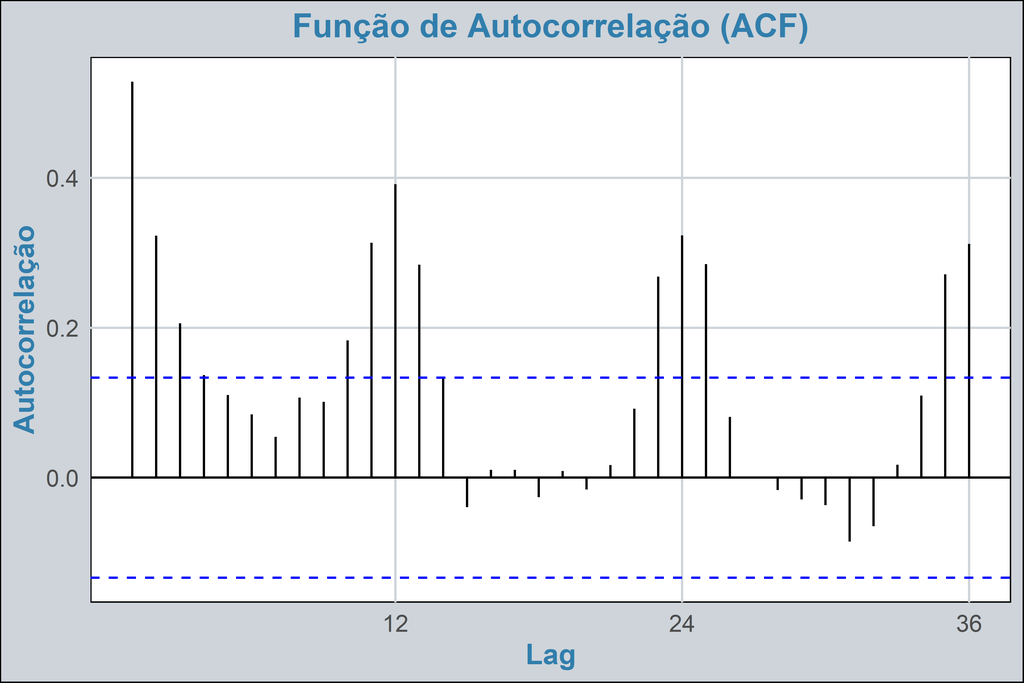

- As barras que ultrapassam as linhas azuis representam autocorrelações estatisticamente significativas. Observa-se que há picos significativos nos primeiros lags, especialmente nos lags 2, 12 e 24, sugerindo dependência temporal na série.
- O comportamento cíclico dos picos de autocorrelação ao redor dos lags 12 e 24 indica a possível presença de sazonalidade anual na série temporal.
- As autocorrelações diminuem lentamente, indicando que a série pode ser não estacionária, ou seja, a média e a variância podem variar ao longo do tempo.

### Gráfico da Função de Autocorrelação Parcial

Para complementar a análise da autocorrelação e identificar possíveis ordens de processos autorregressivos (AR) na série temporal de **velocidade média do vento**, foi calculada a **Função de Autocorrelação Parcial (PACF)**.

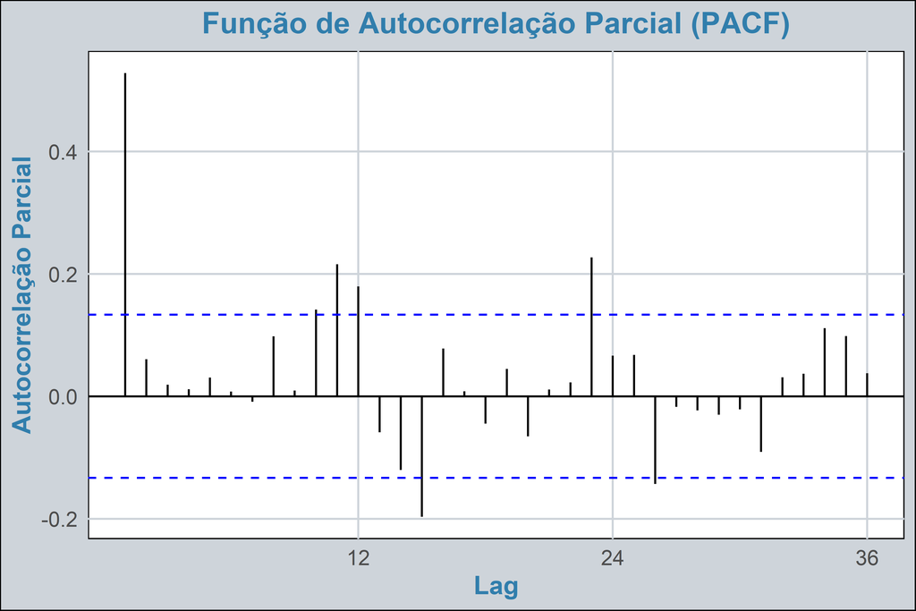

### Decomposição aditiva

A decomposição da série temporal foi realizada para separar os componentes principais: **tendência**, **sazonalidade** e **resíduos (ruídos)**.

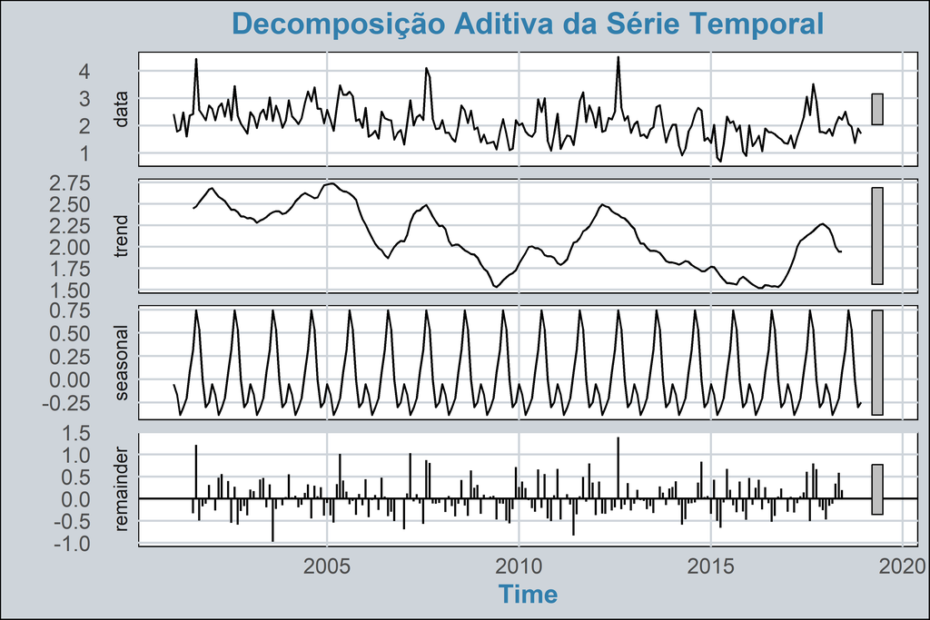

- **Série Original (data)**: A primeira linha do gráfico representa os dados originais da série temporal. Observa-se uma flutuação significativa, com picos em determinados períodos, sugerindo variações sazonais e estruturais.
- **Tendência (trend)**:A linha de tendência destaca variações de longo prazo na série. Nota-se um comportamento declinante entre 2005 e 2015, seguido de uma leve recuperação nos anos finais. Isso indica possíveis mudanças climáticas ou ambientais que influenciam a velocidade média do vento.
- **Sazonalidade (seasonal)**: A terceira linha evidencia um padrão sazonal bem definido ao longo dos anos. As oscilações periódicas têm frequência anual, com picos recorrentes nos mesmos meses, especialmente em julho, agosto e setembro.
- **Resíduos (remainder)**:A última linha representa os resíduos, ou seja, as flutuações não explicadas pelos componentes de tendência e sazonalidade. Os resíduos aparentam ser ruídos aleatórios, mas com alguns períodos de variações mais intensas.

# Testes

### Teste de Ljung-Box para Autocorrelação

O **Teste de Ljung-Box** foi realizado para verificar a presença de autocorrelação significativa nos dados da série temporal. Este teste avalia a hipótese de que os dados são aleatórios ou, em contrapartida, possuem dependência temporal. Dado o p-valor extremamente baixo (5.329e-15), que é menor que o nível de significância usual de 0.05, rejeitamos a hipótese nula (H0). Isso indica que **há autocorrelação significativa na série temporal**.

```
##
##  Box-Ljung test
##
## data:  serie_temporal
## X-squared = 61.124, df = 1, p-value = 5.329e-15
```

```
##
##  studentized Breusch-Pagan test
##
## data:  serie_temporal ~ stats::lag(serie_temporal, -1)
## BP = 0.26749, df = 1, p-value = 0.605
```

### Teste de Normalidade (Anderson-Darling)

O Teste de Anderson-Darling foi aplicado para avaliar a hipótese de que a série temporal segue uma distribuição normal. Este teste verifica a hipótese nula de que os dados seguem uma distribuição normal. O teste revela um p-valor menor que o nível de significância usual (α=0.05), então **rejeitamos a hipótese nula de normalidade**.

```
##
##  Anderson-Darling normality test
##
## data:  serie_temporal
## A = 1.0577, p-value = 0.008696
```

### Testes de Tendência Determinística

Os testes de tendência determinística foram aplicados para avaliar se a série temporal apresenta uma tendência significativa. Cada teste verifica a hipótese nula de que a série não apresenta tendência contra a hipótese alternativa de que há uma tendência presente. Para os testes de Cox-Stuart e Mann-Kendall, os **p-valores** são **0.0**, levando à **rejeição da hipótese nula (H0)** de que a série não possui tendência. Assim, estes testes confirmam a presença de **tendência determinística** significativa na série temporal.

No teste KPSS, o **p-valor** foi **0.1**, indicando que não há evidências suficientes para rejeitar a hipótese nula (**H0**), que assume ausência de tendência. Neste caso, o teste KPSS conclui que **não há tendência determinística significativa**.

A maioria dos testes (Cox-Stuart e Mann-Kendall) aponta a presença de **tendência determinística** na série temporal, enquanto o teste KPSS sugere o contrário. Dado que múltiplos testes indicam **tendência**, podemos concluir que a série apresenta uma **componente de tendência significativa**.

```
##                 Testes            H0 p_valor     Conclusao
## 1           Cox Stuart Não tendência     0.0     Tendência
## 2 Cox and Stuart Trend Não tendência     0.0     Tendência
## 3   Mann-Kendall Trend Não tendência     0.0     Tendência
## 4         Mann-Kendall Não tendência     0.0     Tendência
## 5  KPSS Test for Trend Não tendência     0.1 Não Tendência
```

### Teste de Raiz Unitária

Os testes de raiz unitária foram realizados para verificar a estacionaridade da série temporal. Esses testes avaliam a hipótese nula de que a série apresenta uma raiz unitária (não estacionaridade), contra a hipótese alternativa de que a série é estacionária.

- Ambos os testes **Augmented Dickey-Fuller (ADF)** e **Phillips-Perron (PP)** têm como hipótese nula (**H0**) a presença de raiz unitária (série com tendência estocástica). Como os **p-valores** são **0.01** (menores que 0.05), rejeitamos a hipótese nula, concluindo que **não há tendência estocástica** e a série pode ser considerada **estacionária**.
- O teste **KPSS** possui como hipótese nula (**H0**) a **ausência de tendência** (série estacionária). Como o **p-valor** é **0.01** (menor que 0.05), rejeitamos a hipótese nula e concluímos que a série apresenta **tendência determinística**.

Os resultados indicam que a série temporal **não possui raiz unitária** (não estacionária estocástica) segundo os testes **ADF** e **PP**. No entanto, o teste **KPSS** identifica a presença de uma **tendência determinística**.

```
##                      Testes            H0 p_valor     Conclusao
## 1   Augmented Dickey-Fuller     Tendência    0.01 NAO tendência
## 2 Phillips-Perron Unit Root     Tendência    0.01 NAO tendência
## 3       KPSS Test for Level NAO tendência    0.01     Tendência
```

### Sazonalidade

Os testes de sazonalidade foram realizados para verificar se a série temporal apresenta variações sazonais significativas. Esses testes avaliam a hipótese nula de que a série não apresenta sazonalidade, contra a hipótese alternativa de que a série é sazonal. Os resultados dos testes indicam que tanto o Kruskal-Wallis quanto o Friedman rank apresentam p-valores extremamente baixos. Isso nos permite **rejeitar a hipótese nula de ausência de sazonalidade para ambos os testes**.

```
##           Testes          H0 p_valor Conclusao
## 1 Kruskal-Wallis NAO sazonal       0   Sazonal
## 2  Friedman rank NAO sazonal       0   Sazonal
```

# Séria Temporal Ajustada

Para modelar a série temporal da velocidade média do vento, foi utilizado o modelo **ETS (Erro, Tendência e Sazonalidade)**, especificamente o modelo **ETS(A,N,A)**, que considera:

- **A**: Componente aditivo de erro.
- **N**: Sem componente de tendência.
- **A**: Componente aditivo de sazonalidade.

```
## ETS(A,N,A)
##
## Call:
## ets(y = y)
##
##   Smoothing parameters:
##     alpha = 0.2607
##     gamma = 2e-04
##
##   Initial states:
##     l = 2.4197
##     s = -0.2588 -0.2779 -0.0027 0.5615 0.7598 0.3278
##            0.0496 -0.2963 -0.2712 -0.3873 -0.1685 -0.036
##
##   sigma:  0.4672
##
##      AIC     AICc      BIC
## 789.9152 792.4684 839.6870
##
## Training set error measures:
##                        ME      RMSE       MAE       MPE     MAPE      MASE
## Training set -0.003393119 0.4508941 0.3571875 -4.285033 18.08931 0.6751824
##                    ACF1
## Training set 0.02199055
```

```
##                        ME      RMSE       MAE       MPE     MAPE      MASE
## Training set -0.003393119 0.4508941 0.3571875 -4.285033 18.08931 0.6751824
##                    ACF1
## Training set 0.02199055
```

- O modelo **ETS(A,N,A)** foi capaz de capturar as características da série, especialmente a **sazonalidade** aditiva, como indicado pela estrutura dos estados sazonais.
- As métricas de erro, como **RMSE** e **MAPE**, indicam um ajuste razoável, com o **MAPE** em torno de **18%**, sugerindo uma precisão moderada do modelo.

O modelo foi ajustado com sucesso à série temporal e apresentou métricas de erro aceitáveis. A presença de sazonalidade aditiva foi corretamente modelada, e os resíduos não indicam padrões significativos de autocorrelação.

O gráfico abaixo apresenta a comparação entre os valores **observados** da série temporal (em preto) e os valores **ajustados** pelo modelo **ETS(A,N,A)** (em vermelho).

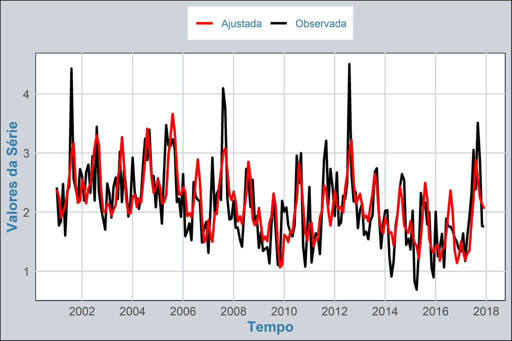

### Previsão

A previsão foi realizada utilizando o modelo **ETS(A,N,A)**, que incorpora uma estrutura aditiva de erro e sazonalidade, sem tendência. O gráfico abaixo apresenta os valores observados e as previsões futuras, com os respectivos **intervalos de confiança** de 80% e 95%.

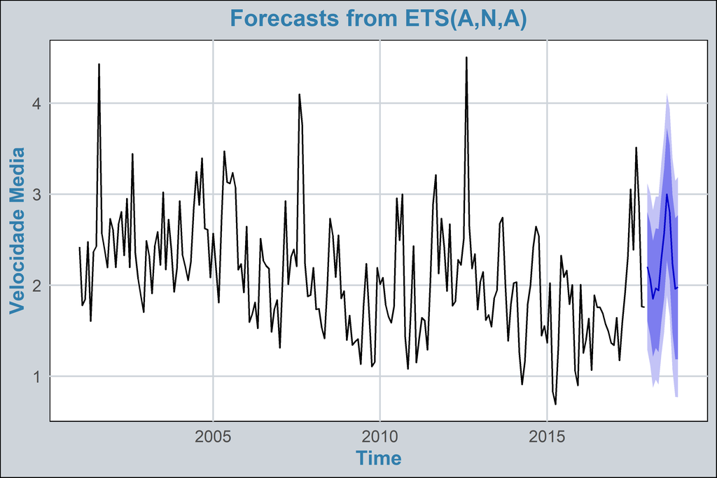

### Análise dos Resíduos

- Os resíduos oscilam em torno de zero e não apresentam padrões visíveis, sugerindo que o modelo ajustou bem a série temporal e não deixou estrutura não explicada.
- O gráfico de ACF mostra que as autocorrelações estão dentro dos limites de confiança, indicando que os resíduos são próximos de ruído branco. Não há evidências de autocorrelação significativa.
- O histograma revela que os resíduos estão aproximadamente distribuídos normalmente, com leve assimetria. A curva ajustada (em laranja) sugere um bom ajuste da distribuição.

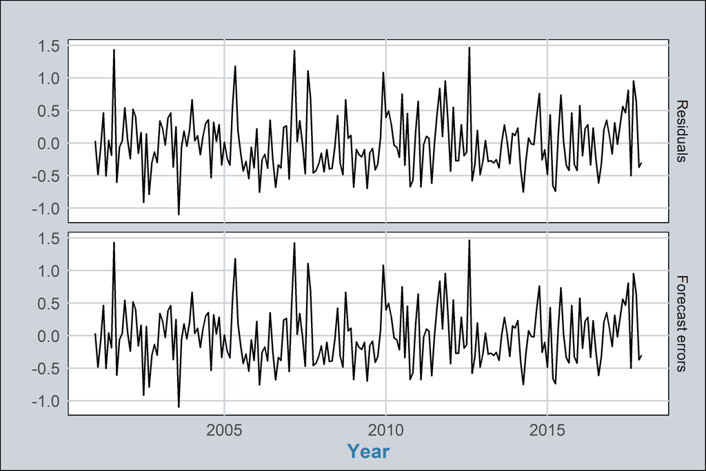

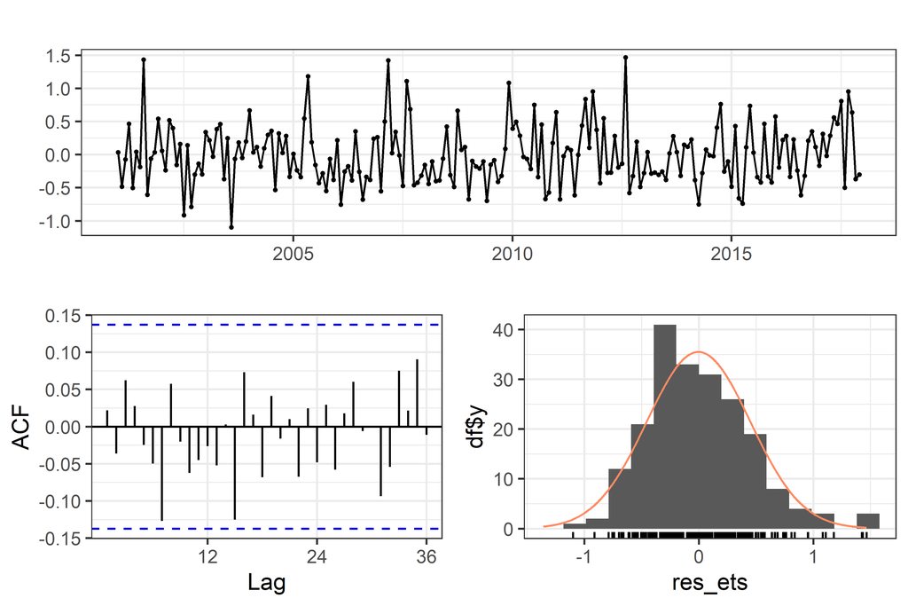

#### Teste de Normalidade

No gráfico abaixo, os pontos representam os resíduos do modelo, enquanto a linha preta indica a distribuição normal teórica. Os resíduos próximos à linha sugerem que eles seguem aproximadamente uma distribuição normal.Os resíduos apresentam uma aproximação razoável à normalidade, com pequenos desvios nos extremos.

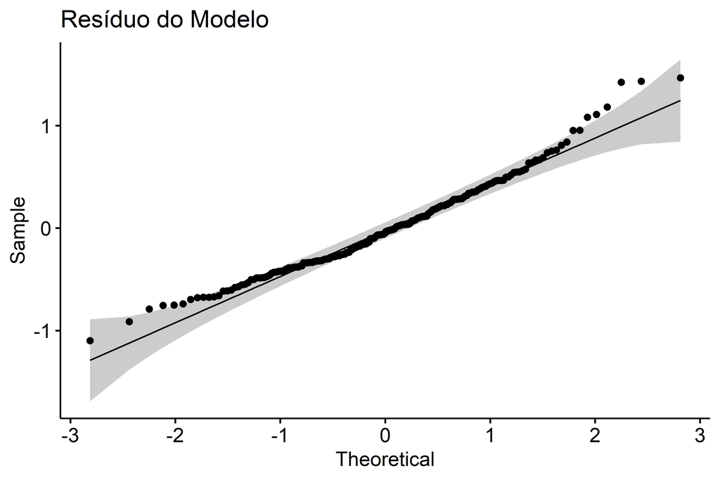

```
##
##  Shapiro-Wilk normality test
##
## data:  res_ets
## W = 0.97351, p-value = 0.0006769
```

```
##
##  Augmented Dickey-Fuller Test
##
## data:  res_ets
## Dickey-Fuller = -5.7784, Lag order = 5, p-value = 0.01
## alternative hypothesis: stationary
```

- O teste de Shapiro-Wilk indica que os resíduos não são exatamente normais, possuindo pequenas assimetrias ou caudas mais pesadas. Apesar disso, o desvio é leve e pode não comprometer a adequação do modelo.
- O teste ADF confirma que os resíduos são estacionários, uma condição necessária para um modelo bem ajustado.

#### Teste de Correlação

Os resultados do Teste de Box-Pierce confirmam que os resíduos do modelo ETS(A,N,A) não apresentam autocorrelação significativa. Esse diagnóstico reforça a adequação do modelo, uma vez que os resíduos independentes são uma condição importante para a validade das previsões.

```
##
##  Box-Pierce test
##
## data:  res_ets
## X-squared = 6.7737, df = 10, p-value = 0.7466
```

# Conclusão

A análise da série temporal da **velocidade média do vento** em Brasília revelou padrões sazonais claros e uma tendência determinística, confirmados por testes estatísticos e análise gráfica. O modelo **ETS(A,N,A)**, ajustado aos dados, apresentou um desempenho satisfatório, capturando adequadamente a sazonalidade e a variabilidade da série. As métricas de erro, como **RMSE** (0.4509) e **MAPE** (18.09%), indicaram boa precisão, com pequenas discrepâncias nos picos.

A análise dos resíduos confirmou a **adequação do modelo**, com resíduos **estacionários**, **independentes** e próximos de ruído branco, conforme demonstrado pelo **Teste de Augmented Dickey-Fuller** e **Box-Pierce**. Apesar de uma leve violação da normalidade observada no **Teste de Shapiro-Wilk**, a independência e estacionariedade dos resíduos garantem a confiabilidade das previsões.

As previsões realizadas mantiveram a sazonalidade identificada, com intervalos de confiança consistentes. Assim, o modelo ETS(A,N,A) pode ser considerado apropriado para a série analisada, sendo útil para estimativas futuras da **velocidade média do vento**.

# Referências

BISOGNIN, C. *Notas de Aula - STC1086: Séries Temporais I*. Universidade Federal de Santa Maria, Departamento de Estatística, Centro de Ciências Naturais e Exatas, 2023.